# Machine Learning Engineer Nanodegree

## Project: Train a Smartcab to Drive

Welcome to the fourth project of the Machine Learning Engineer Nanodegree! In this notebook, template code has already been provided for you to aid in your analysis of the *Smartcab* and your implemented learning algorithm. You will not need to modify the included code beyond what is requested. There will be questions that you must answer which relate to the project and the visualizations provided in the notebook. Each section where you will answer a question is preceded by a **'Question X'** header. Carefully read each question and provide thorough answers in the following text boxes that begin with **'Answer:'**. Your project submission will be evaluated based on your answers to each of the questions and the implementation you provide in `agent.py`.

> **Note:** Code and Markdown cells can be executed using the **Shift + Enter** keyboard shortcut. In addition, Markdown cells can be edited by typically double-clicking the cell to enter edit mode.

## Comments for Reviewer 1, Reviewer 2, and Udacity

This is a second revision of this project following the comments of the reviewer of the first revision. I would like to provide my feedback for both the reviewers of this project and for Udacity project reviewing practices in general.

1. First of all, I would like to thank reviewer 2 for the two comments on the code itself, especially the second one (the missing (1-alpha) term). This is a great catch. Thanks a lot!
2. I would also like to mention that reviewer 1 did not catch this point. With all due respect, this is a major bug in the most important core line of the code that should have been caught in a code review.
3. The most important point, which made me write this entire Comments section. The two reviewers apparently contradict each other on one of the project points: whether one should include a certain feature into the agent state. While it is okay to have different opinions on a specific point, I would expect the rewiers to at least check the preceding versions of the project and read the preceding review. Even less than that, reviewer 2 could have checked the diffs between the two submissions on github. They are very short and would not take more than a couple of minutes to look at.

   The controversial point is the answer to Question 4 regarding whether to include `input-right` feature into the agent state. Here is a more detailed description of this point:
   - `inputs-right:` **NO** In the suggested model, there is no situation when a vehicle on the right of the agent may affect the agent's safety. If the light feature is taken into account and the agent learned to obey the traffic light, it can only drive on red when turning right. Turning right never intesects traffic from the right trajectory. Thus, this feature can safely be ignored.

     The paragraph above is my answer to the question in this version of the project submissoin. It is identical to my answer to this question in the first submission of this project. I have copied and pasted it back here. The first reviewer strongly suggested that I change this point. Here are his comments:

     > US traffic laws make right unnecessary. This said, while excluding right makes sense for a human, including right makes the problem closer to one an actual AI might face. Actual traffic laws are far too complex to explain in a series of if-then statements, not to mention that many human drivers treat traffic laws as "flexible". The spirit of the project is for the agent to learn that right is not necessary. The agent should be able to in less than 400 trials, depending upon your learning rate and exploration decay rate.

     > In eliminating features beyond deadline, your project is verging on being a knowledge-based approach to AI [reference]. This is a reinforcement learning project which means you must teach the AI to learn, not program its behavior. You are technically allowed to restrict its input to some extent, but it should be choosing actions based upon its own learning. Note that this may take hundreds of trials to be successful.

     > In terms of learning the theory behind the project, here you only have six inputs. If you had 6000 inputs, would you know which features to eliminate? In my opinion, the best solution to this project is one in which has many features as possible are included and the agent is allowed to learn for itself which features are important. If you were to include all four inputs and the waypoint feature, it wouldn't take you more than 400 or 500 trails to train your agent. In this reinforcement learning task, its fine to run hundreds or thousands of trials. Tesla collected hundreds of millions of miles of data before it activated its self-driving car software! </blockquote> In my revision following this review, I took this suggestion into account. Here is my answer to this point in that revision:

     > > `inputs-right:`**YES** In my original submission I judged that this feature should not be part of the state. The reasoning behind this is quite simple and can be found in the original version of this notebook on github. As was suggested by the reviewer, I am including this feature into the agent's state to let the agent learn from experience that this feature is irrelavant to the optimal behavior.  
     > > I would like to shortly comment on the reviewer's point on the knowledge-based approach to AI versus the learning-based approach. I agree with each point the reviewer made. Also, this particular project is a very simple toy problem, for which any approach can work successfully. It is worth pointing out though, that when dealing with real reinforcement learning problems, it is critical to use every constraint possible to improve the RL convergence. Even taking into account recent drastical increase in computational productivity, using each possible constraint may turn out to be critical for disclosing more "farther lying" properties of the world. </blockquote> And, finally, the reviewer 2 comments on this point:

     > > > Since the previous reviewer has already passed this I will let it pass but think of the following:  
     > > > Recommendations  
     > > > A few things to keep in mind:

     > > > The reward system follows the U.S driving laws.  
     > > > There are no U-turns allowed in our world of the smartcab

     > > > Keeping these in mind can you check if all of these state variables are required or can some of them be dropped?

     > > > waypoint,  
     > > > light,  
     > > > oncoming,  
     > > > right,  
     > > > left

     > > > Let me make it easy for you. One of the above is redundant (i.e any car coming from that direction cannot interfere with an agent that is following the rules. or to put it simply it would not matter if you removed that state variable, the agent can still learn the rules without any issues.)

   Thank you,

   Michael Kositsky

## Getting Started

In this project, you will work towards constructing an optimized Q-Learning driving agent that will navigate a *Smartcab* through its environment towards a goal. Since the *Smartcab* is expected to drive passengers from one location to another, the driving agent will be evaluated on two very important metrics: **Safety** and **Reliability**. A driving agent that gets the *Smartcab* to its destination while running red lights or narrowly avoiding accidents would be considered **unsafe**. Similarly, a driving agent that frequently fails to reach the destination in time would be considered **unreliable**. Maximizing the driving agent's **safety** and **reliability** would ensure that *Smartcabs* have a permanent place in the transportation industry.

**Safety** and **Reliability** are measured using a letter-grade system as follows:

| Grade | Safety | Reliability |
| --- | --- | --- |
| A+ | Agent commits no traffic violations, and always chooses the correct action. | Agent reaches the destination in time for 100% of trips. |
| A | Agent commits few minor traffic violations, such as failing to move on a green light. | Agent reaches the destination on time for at least 90% of trips. |
| B | Agent commits frequent minor traffic violations, such as failing to move on a green light. | Agent reaches the destination on time for at least 80% of trips. |
| C | Agent commits at least one major traffic violation, such as driving through a red light. | Agent reaches the destination on time for at least 70% of trips. |
| D | Agent causes at least one minor accident, such as turning left on green with oncoming traffic. | Agent reaches the destination on time for at least 60% of trips. |
| F | Agent causes at least one major accident, such as driving through a red light with cross-traffic. | Agent fails to reach the destination on time for at least 60% of trips. |

To assist evaluating these important metrics, you will need to load visualization code that will be used later on in the project. Run the code cell below to import this code which is required for your analysis.

```python
# Import the visualization code
import visuals as vs

# Pretty display for notebooks
%matplotlib inline
```

### Understand the World

Before starting to work on implementing your driving agent, it's necessary to first understand the world (environment) which the *Smartcab* and driving agent work in. One of the major components to building a self-learning agent is understanding the characteristics about the agent, which includes how the agent operates. To begin, simply run the `agent.py` agent code exactly how it is -- no need to make any additions whatsoever. Let the resulting simulation run for some time to see the various working components. Note that in the visual simulation (if enabled), the **white vehicle** is the *Smartcab*.

### Question 1

In a few sentences, describe what you observe during the simulation when running the default `agent.py` agent code. Some things you could consider:

- *Does the Smartcab move at all during the simulation?*
- *What kind of rewards is the driving agent receiving?*
- *How does the light changing color affect the rewards?*

**Hint:** From the `/smartcab/` top-level directory (where this notebook is located), run the command

```
'python smartcab/agent.py'
```

**Answer:**

- *Does the Smartcab move at all during the simulation?*  
  No, the Smartcab does not move during this simulation.
- *What kind of rewards is the driving agent receiving? How does the light changing color affect the rewards?*  
  The agent receives a small positive reward when idling at a red light. The agent receives higher negative rewards when it is idling at a green light.

### Understand the Code

In addition to understanding the world, it is also necessary to understand the code itself that governs how the world, simulation, and so on operate. Attempting to create a driving agent would be difficult without having at least explored the *"hidden"* devices that make everything work. In the `/smartcab/` top-level directory, there are two folders: `/logs/` (which will be used later) and `/smartcab/`. Open the `/smartcab/` folder and explore each Python file included, then answer the following question.

### Question 2

- *In the* `agent.py` *Python file, choose three flags that can be set and explain how they change the simulation.*
- *In the* `environment.py` *Python file, what Environment class function is called when an agent performs an action?*
- *In the* `simulator.py` *Python file, what is the difference between the* `'render_text()'` *function and the* `'render()'` *function?*
- *In the* `planner.py` *Python file, will the* `next_waypoint()` *function consider the North-South or East-West direction first?*

**Answer:**

- *In the agent.py Python file, choose three flags that can be set and explain how they change the simulation.*  
  Three flags that can be set in LerningAgent class are:
  1. `learning` - This is a boolean flag that specifies whether the agent learns at all during a trial. "The agent learns" means any parameters that determine the agent's behavoir are updated during a trial. When the learning flag is turned on, several parameters of the agent are updated at each step. When the flag is turned off, the agent's parameters are never updated.
  2. `epsilon` - This parameter regulates the exploration-exploitation trade off. The code yet to be written inside the choose_action method will implement epsilon-greedy exploration.
  3. `alpha` - The learning rate for updating the Q-value estimation. This parameter will be used in the `learn` method where the Q-value estimation will be updated at every step.
- *In the environment.py Python file, what Environment class function is called when an agent performs an action?*  
  When an agent performs an action, the Environment method `act` is called.
- *In the simulator.py Python file, what is the difference between the 'render_text()' function and the 'render()' function?*  
  The `renter_text` function prints out trial information in the comand prompt window. The `render` function updates the graphical reflection of the road grid and all agents in the GUI window.
- *In the planner.py Python file, will the next_waypoint() function consider the North-South or East-West direction first?*  
  The `next_waypoint` function considers the East-West direction first.

## Implement a Basic Driving Agent

The first step to creating an optimized Q-Learning driving agent is getting the agent to actually take valid actions. In this case, a valid action is one of `None`, (do nothing) `'left'` (turn left), `right'` (turn right), or `'forward'` (go forward). For your first implementation, navigate to the `'choose_action()'` agent function and make the driving agent randomly choose one of these actions. Note that you have access to several class variables that will help you write this functionality, such as `'self.learning'` and `'self.valid_actions'`. Once implemented, run the agent file and simulation briefly to confirm that your driving agent is taking a random action each time step.

### Basic Agent Simulation Results

To obtain results from the initial simulation, you will need to adjust following flags:

- `'enforce_deadline'` - Set this to `True` to force the driving agent to capture whether it reaches the destination in time.
- `'update_delay'` - Set this to a small value (such as `0.01`) to reduce the time between steps in each trial.
- `'log_metrics'` - Set this to `True` to log the simluation results as a `.csv` file in `/logs/`.
- `'n_test'` - Set this to `'10'` to perform 10 testing trials.

Optionally, you may disable to the visual simulation (which can make the trials go faster) by setting the `'display'` flag to `False`. Flags that have been set here should be returned to their default setting when debugging. It is important that you understand what each flag does and how it affects the simulation!

Once you have successfully completed the initial simulation (there should have been 20 training trials and 10 testing trials), run the code cell below to visualize the results. Note that log files are overwritten when identical simulations are run, so be careful with what log file is being loaded! Run the agent.py file after setting the flags from projects/smartcab folder instead of projects/smartcab/smartcab.

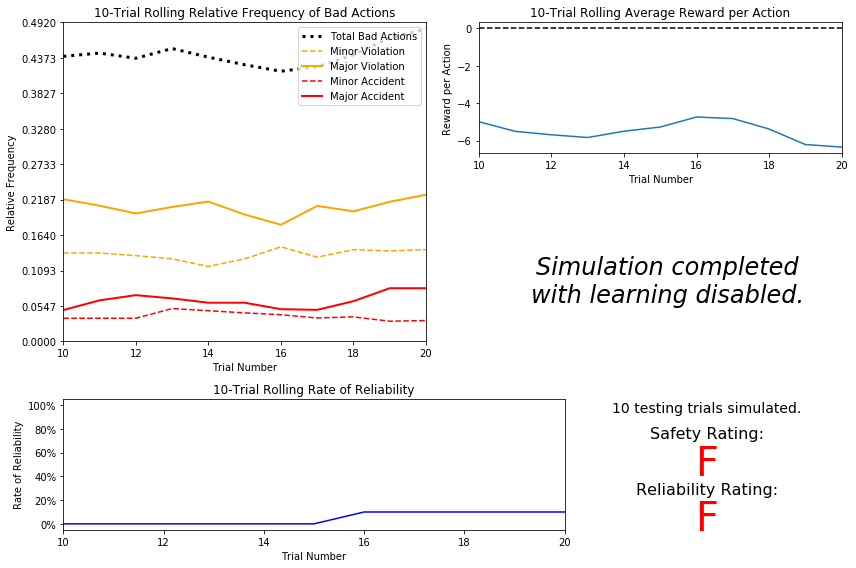

```python
# Load the 'sim_no-learning' log file from the initial simulation results
vs.plot_trials('sim_no-learning.csv')
```

### Question 3

Using the visualization above that was produced from your initial simulation, provide an analysis and make several observations about the driving agent. Be sure that you are making at least one observation about each panel present in the visualization. Some things you could consider:

- *How frequently is the driving agent making bad decisions? How many of those bad decisions cause accidents?*
- *Given that the agent is driving randomly, does the rate of reliability make sense?*
- *What kind of rewards is the agent receiving for its actions? Do the rewards suggest it has been penalized heavily?*
- *As the number of trials increases, does the outcome of results change significantly?*
- *Would this Smartcab be considered safe and/or reliable for its passengers? Why or why not?*

## Inform the Driving Agent

The second step to creating an optimized Q-learning driving agent is defining a set of states that the agent can occupy in the environment. Depending on the input, sensory data, and additional variables available to the driving agent, a set of states can be defined for the agent so that it can eventually *learn* what action it should take when occupying a state. The condition of `'if state then action'` for each state is called a **policy**, and is ultimately what the driving agent is expected to learn. Without defining states, the driving agent would never understand which action is most optimal -- or even what environmental variables and conditions it cares about!

### Identify States

Inspecting the `'build_state()'` agent function shows that the driving agent is given the following data from the environment:

- `'waypoint'`, which is the direction the *Smartcab* should drive leading to the destination, relative to the *Smartcab*'s heading.
- `'inputs'`, which is the sensor data from the *Smartcab*. It includes
  - `'light'`, the color of the light.
  - `'left'`, the intended direction of travel for a vehicle to the *Smartcab*'s left. Returns `None` if no vehicle is present.
  - `'right'`, the intended direction of travel for a vehicle to the *Smartcab*'s right. Returns `None` if no vehicle is present.
  - `'oncoming'`, the intended direction of travel for a vehicle across the intersection from the *Smartcab*. Returns `None` if no vehicle is present.
- `'deadline'`, which is the number of actions remaining for the *Smartcab* to reach the destination before running out of time.

### Question 4

*Which features available to the agent are most relevant for learning both **safety** and **efficiency**? Why are these features appropriate for modeling the* Smartcab *in the environment? If you did not choose some features, why are those features* not *appropriate? Please note that whatever features you eventually choose for your agent's state, must be argued for here. That is: your code in agent.py should reflect the features chosen in this answer.*

NOTE: You are not allowed to engineer new features for the smartcab.

**Answer:** Let us consider each of the features:

- `waypoint:` **YES** This feature is absolutely necessary for learning an efficient behavior. The agent must know the correct next target at each intersection in order to learn a proper action to reach it. This is necessary for learning efficiency.
- `inputs-light:` **YES** This feature is necessary to learn to avoid traffic violations and accidents. This is necessary for learning safety.
- `inputs-left:` **YES** At a first glance, if the agent knows the light and learned to only drive at green, it is not necessary to know whether there is a vehicle on the left and what is its intended direction. However, since it is allowed to turn right on red, the agent must take the vehicle on the left into the account when the latter intends to drive straight. In such a case, the agent must yield to the vehicle on the left. Thus, this feature must be included for learning safety.
- `inputs-right:` **NO** In the suggested model, there is no situation when a vehicle on the right of the agent may affect the agent's safety. If the light feature is taken into account and the agent learned to obey the traffic light, it can only drive on red when turning right. Turning right never intesects traffic from the right trajectory. Thus, this feature can safely be ignored.

  The paragraph above is identical to my answer to this question in the first submission of this project. I have copied and pasted it back here. Please check the section "Comments for Reviewer 1, Reviewer 2, and Udacity" at the top of this document for a detailed discussion of this point.
- `inputs-oncoming:` **YES** This feature is necessary to avoid accidents when turning left on green light. The agent must learn to yield to the oncoming traffic when turning left on green. This feature is critical for learning for safety.
- `deadline:` **NO** The deadline does not affect what the agent should choose as an immediate action. I must admit that initially I tried to use the deadline as a state feature. My reasoning was as follows: one can think of the Q function, which would depend on the deadline since it affects the projected long term cumulative future reward collected starting from a certain state. I even received quite good learning results for optimized Q-Learner including deadline among state features: I received the safety rating A+ and reliability rating A. However, when I got to the end of the project, I realized that the gamma * argmax(Q(s',a)) term is never going to be used. In this case, including the deadline among state features only unnecessarily increases the number of different states and slows down learning. I then redid all the computations from this point down without the deadline feature. It provides more efficient learning for the initial and optimized Q-Learners. See the results below.

### Define a State Space

When defining a set of states that the agent can occupy, it is necessary to consider the *size* of the state space. That is to say, if you expect the driving agent to learn a **policy** for each state, you would need to have an optimal action for *every* state the agent can occupy. If the number of all possible states is very large, it might be the case that the driving agent never learns what to do in some states, which can lead to uninformed decisions. For example, consider a case where the following features are used to define the state of the *Smartcab*:

`('is_raining', 'is_foggy', 'is_red_light', 'turn_left', 'no_traffic', 'previous_turn_left', 'time_of_day')`.

How frequently would the agent occupy a state like `(False, True, True, True, False, False, '3AM')`? Without a near-infinite amount of time for training, it's doubtful the agent would ever learn the proper action!

### Question 5

*If a state is defined using the features you've selected from **Question 4**, what would be the size of the state space? Given what you know about the environment and how it is simulated, do you think the driving agent could learn a policy for each possible state within a reasonable number of training trials?*  
**Hint:** Consider the *combinations* of features to calculate the total number of states!

**Answer:** The total number of states is a product of all the numbers of values for all the features:

| feature | number of values |
| --- | --- |
| `waypoint` | 3 |
| `inputs-light` | 2 |
| `inputs-left` | 4 |
| `inputs-oncoming` | 4 |
| **Total:** | **96** |